# final_project_data_exploration

lets look at data

Andrew Imredy

**To start, lets read in our data and summarize it**

```r
library(tidyverse)
df <- read.csv('cs_1675_fall2021_finalproject.csv')
summary(df)
```

```
##        x1                 x2                 x3                 x4
##  Min.   :0.003117   Min.   :0.001173   Min.   :0.003344   Min.   :0.001447
##  1st Qu.:0.144825   1st Qu.:0.059488   1st Qu.:0.180333   1st Qu.:0.034732
##  Median :0.278602   Median :0.170552   Median :0.263551   Median :0.055822
##  Mean   :0.265192   Mean   :0.159282   Mean   :0.262674   Mean   :0.053189
##  3rd Qu.:0.352812   3rd Qu.:0.238338   3rd Qu.:0.343556   3rd Qu.:0.072108
##  Max.   :0.609092   Max.   :0.446306   Max.   :0.509710   Max.   :0.101868
##        v1                  v2                 v3               v4
##  Min.   : 0.003474   Min.   :0.002281   Min.   : 1.003   Min.   :0.01867
##  1st Qu.: 3.335833   1st Qu.:0.334104   1st Qu.: 3.945   1st Qu.:0.30184
##  Median : 5.137150   Median :0.515154   Median : 5.632   Median :0.48923
##  Mean   : 5.079560   Mean   :0.503186   Mean   : 5.569   Mean   :0.49132
##  3rd Qu.: 6.850576   3rd Qu.:0.684780   3rd Qu.: 7.189   3rd Qu.:0.67959
##  Max.   :10.133807   Max.   :1.018897   Max.   :10.177   Max.   :0.97913
##        v5                 m                 output
##  Min.   : 0.006831   Length:1252        Min.   :0.0070
##  1st Qu.: 2.439787   Class :character   1st Qu.:0.2517
##  Median : 6.496589   Mode  :character   Median :0.4835
##  Mean   : 5.867330                      Mean   :0.5311
##  3rd Qu.: 9.328919                      3rd Qu.:0.8430
##  Max.   : 9.999845                      Max.   :0.9990
```

Okay, that doesn’t tell us all that much. v1, v3, and v5 are an order of magnitude larger than the other inputs. But most inputs are between 0 and 1.

**First transform y to logit(y)**

```r
df <- df %>%
  mutate(y = boot::logit(output))
```

**Let’s make some plots**

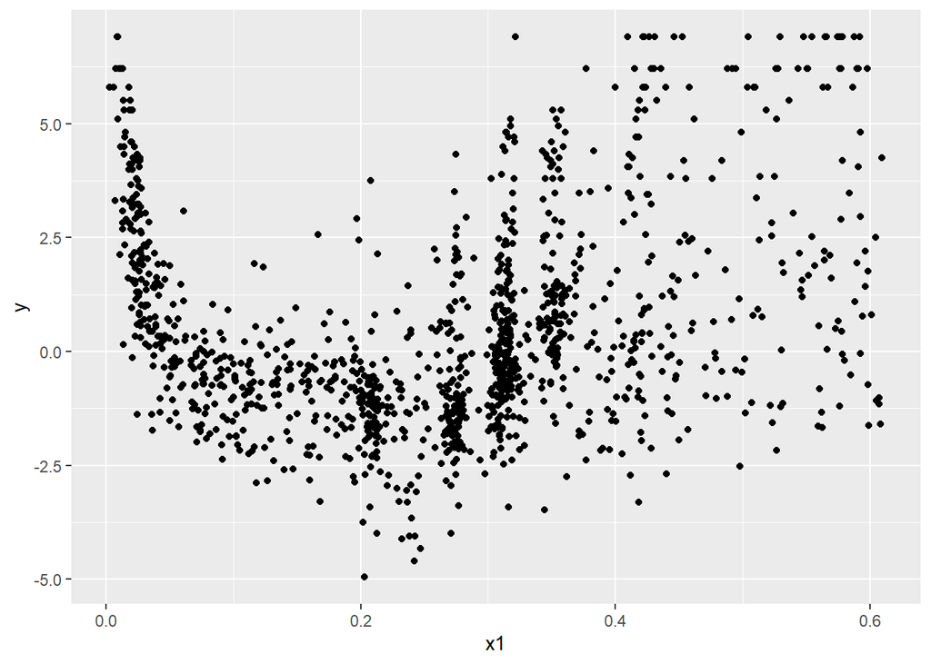

```r
df %>% ggplot(mapping = aes(x = x1, y = y)) + geom_point()
```

Interesting. Seems like an upward-facing parabolic trend, with more noise as x1 gets larger. Also some clusters around x1 = .3. Let’s try another

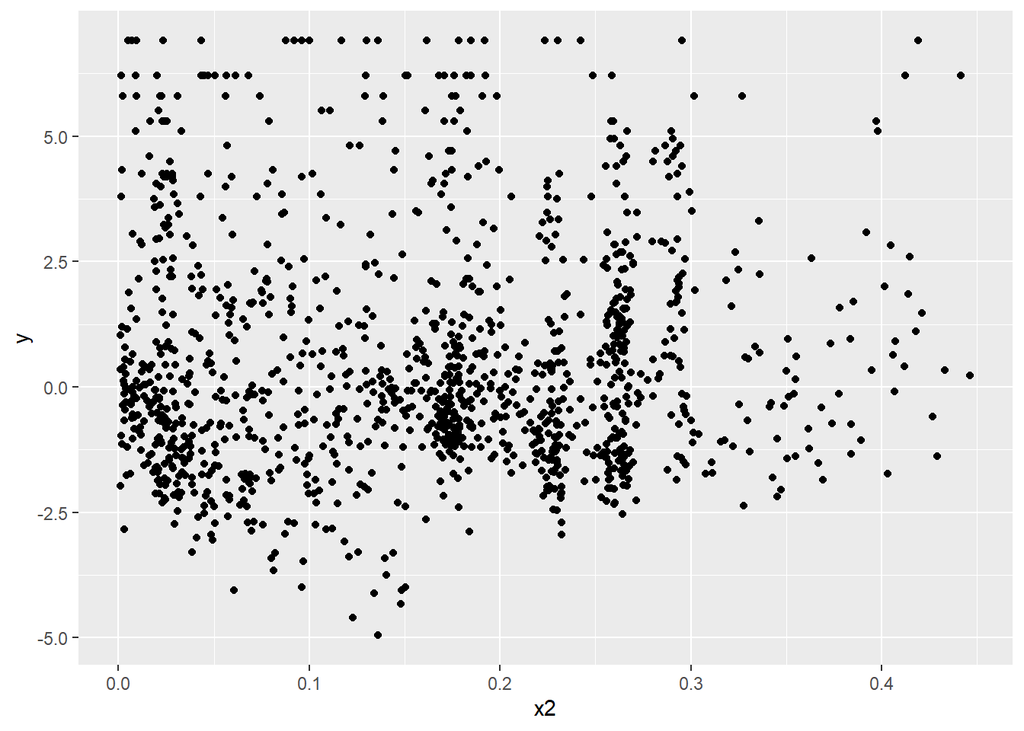

```r
df %>% ggplot(mapping = aes(x = x2, y = y)) + geom_point()
```

Little visible correlation. But we can see that most values of x2 are < .3, and a lot of observations are nearly 100% corroded.

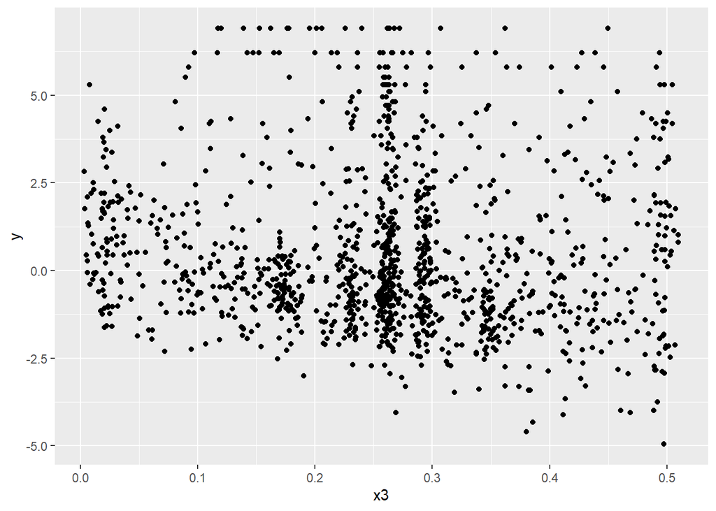

```r
df %>% ggplot(mapping = aes(x = x3, y = y)) + geom_point()
```

Sheesh, not making it easy. A slight negative correlation here if we look at the low-corrosion samples. Also a few clusters around x3 = .25.

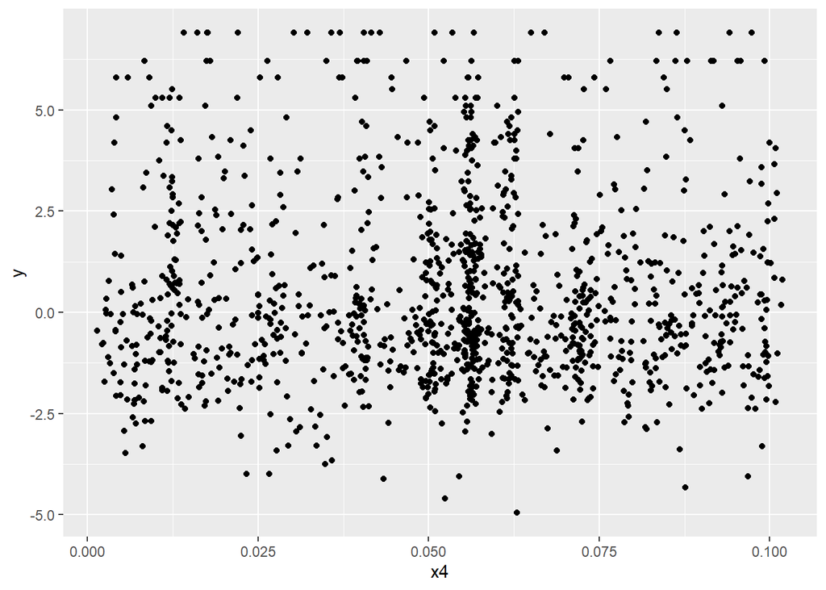

```r
df %>% ggplot(mapping = aes(x = x4, y = y)) + geom_point()
```

**Let’s mutate the dataframe to include derived inputs!**

```r
df <- df %>%
  mutate(x5 = 1 - (x1 + x2 + x3 + x4),
         w = x2 / (x3 + x4),
         z = (x1 + x2) / (x5 + x4),
         t = v1 * v2)
```

**More plots okay**

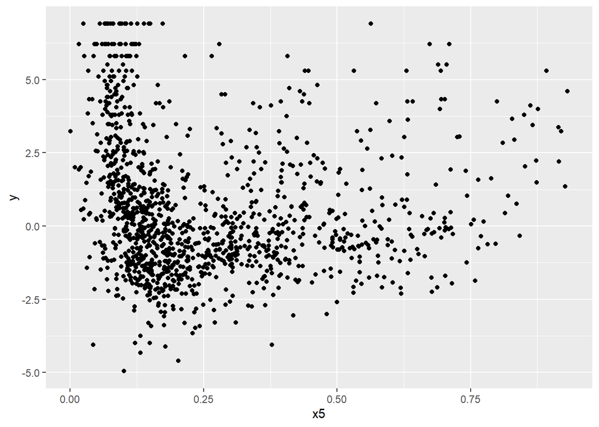

```r
df %>% ggplot(mapping = aes(x = x5, y = y)) + geom_point()
```

Ooh, looks like a trend. Response rapidly decreases from 0 to .13ish, then levels off or even increases.

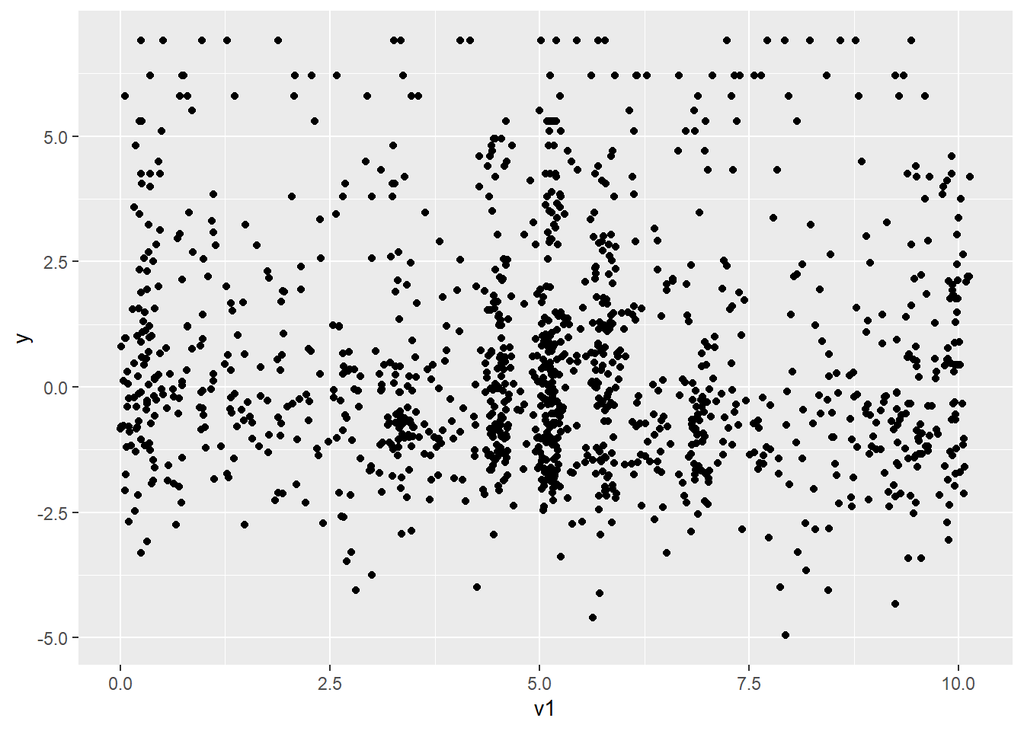

```r
df %>% ggplot(mapping = aes(x = v1, y = y)) + geom_point()
```

Not much here imo.

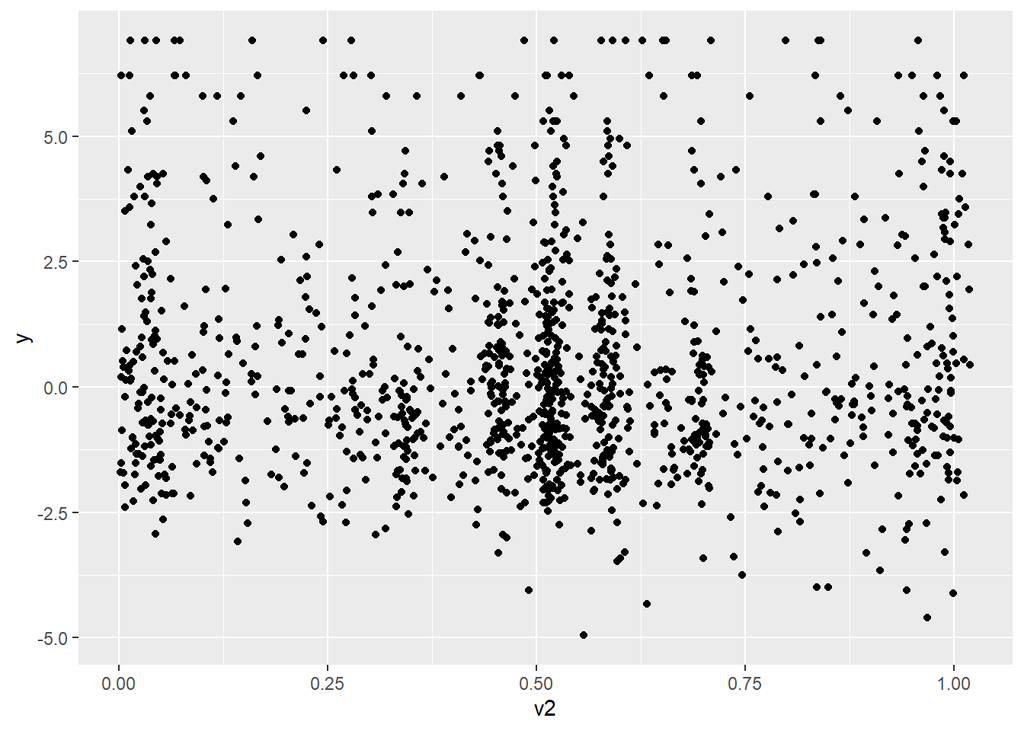

```r
df %>% ggplot(mapping = aes(x = v2, y = y)) + geom_point()
```

eh, nothing much here either

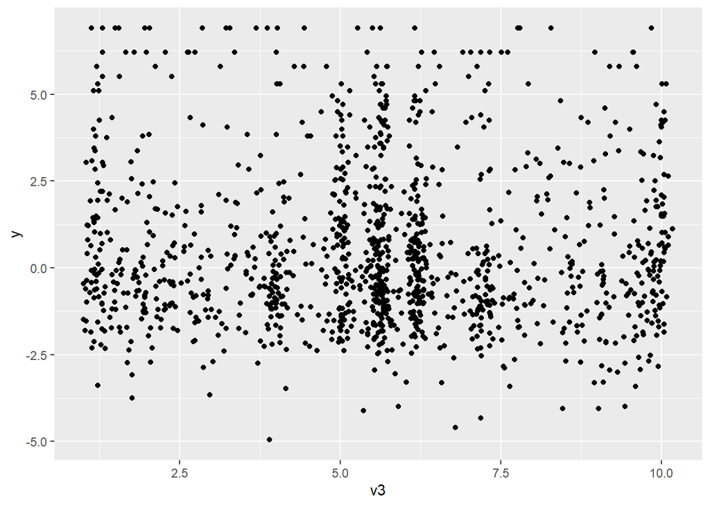

```r
df %>% ggplot(mapping = aes(x = v3, y = y)) + geom_point()
```

All the vs have a similar plot, with some clusters around the median, but no apparent correlation.

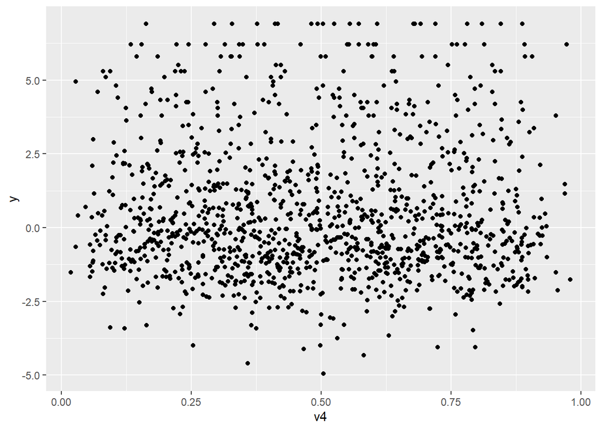

```r
df %>% ggplot(mapping = aes(x = v4, y = y)) + geom_point()
```

Very evenly distributed points here.

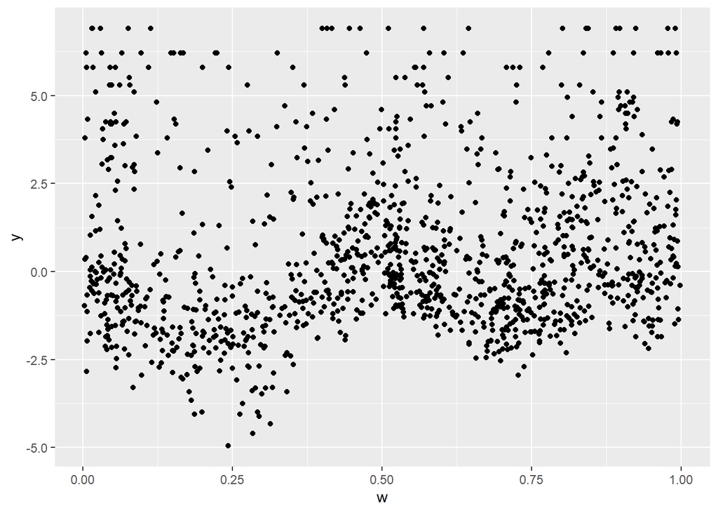

```r
df %>% ggplot(mapping = aes(x = w, y = y)) + geom_point()
```

Alright, some kind of polynomialish correlation.

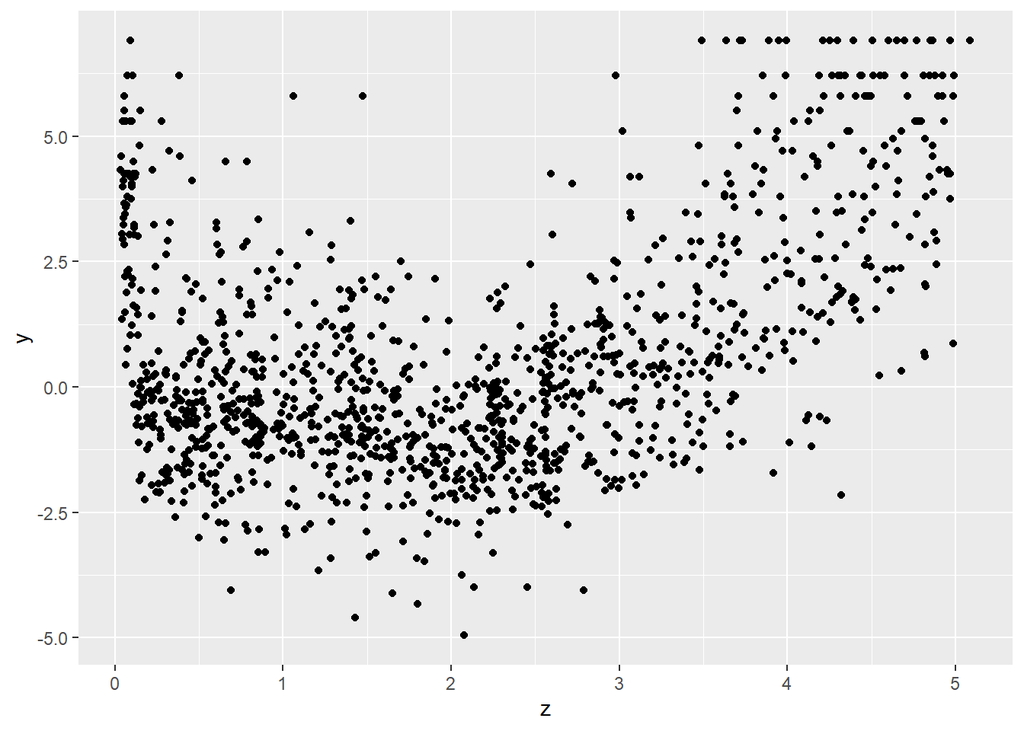

```r
df %>% ggplot(mapping = aes(x = z, y = y)) + geom_point()
```

A nice parabolic correlation!

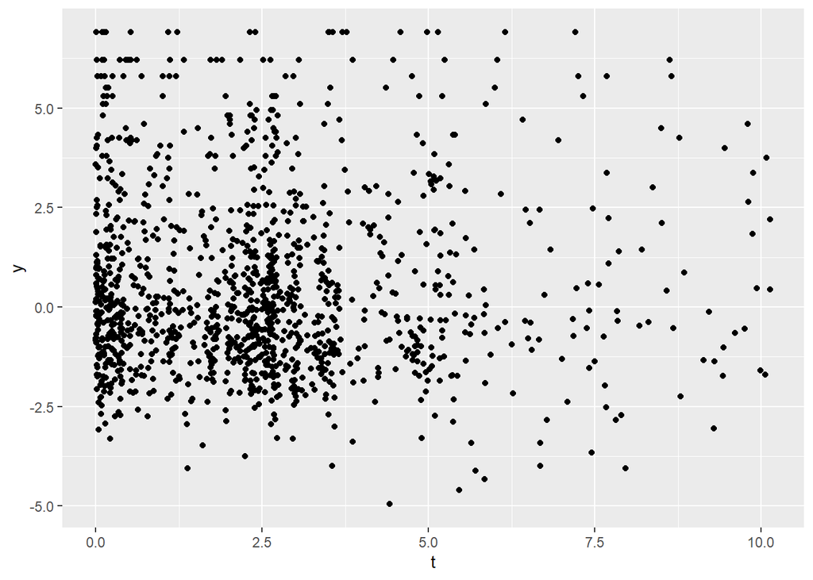

```r
df %>% ggplot(mapping = aes(x = t, y = y)) + geom_point()
```

Nothing apparent..

**Okay, looks like x1, x5, w, and z have the strongest correlations.**

**Hold up, let’s try the machine**

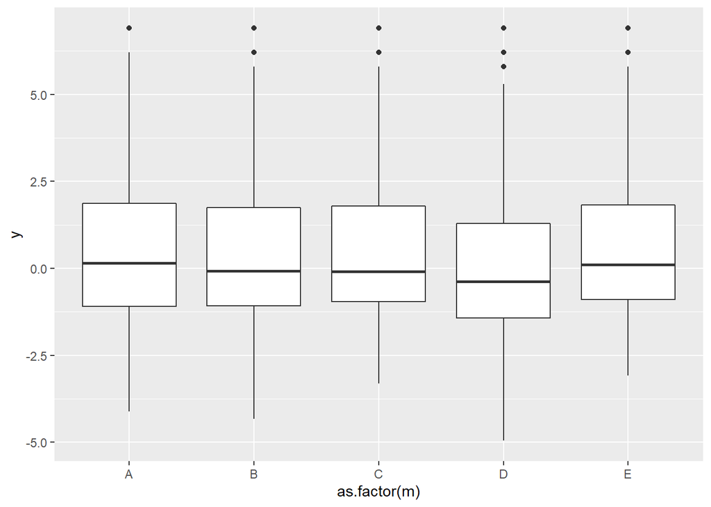

```r
df %>% ggplot(mapping = aes(x = as.factor(m), y = y)) + geom_boxplot()
```

Machine D seems best, but it’s not a huge difference. Perhaps we should look at the correlations between inputs and output for different machines. But it’s 10:30 on a Thursday so we’re done with our initial exploration :)